# Social Networks and Spatial Mobility

Lika Zhvania | 29.08.2022 MSc thesis: ‘Connecting social network to mobility - comparison of the spatial pattern of mobility and the location of call partners based on passive mobile positioning dataset’ MSc, Geoinformatics for Urbanised Society Department of Geography, University of Tartu

# 1 Project description

# 2 Data

## 2.1 Data description

The primary data which is used in the thesis research, is the passive mobile positioning data, in particular, Call Detail Records (CDR), Call Graph. The data is obtained by the mobile network operators and contains information about the time and location of the call, identifications of the call initiator and receiver. The locations of the calls are aggregated by the closest antenna that receives the signal from while calling. The data has dyadic characteristics.

## 2.2 Libraries and Tools

The list of libraries that is or might be used during analysis:

```r
# Main
#library(rmarkdown) # dynamic documents for R, combining code, rendered output and prose.
#library(tidyverse) # an opinionated collection of R packages designed for data science
#library(sf) # Simple features: support for simple features, a standardized way to encode spatial vector data
#library(lubridate) # to work with dates and times
#library(stringr)  # for manipulations on text
#library(ggplot2) # visualization package
#library(hrbrthemes) # additional themes and theme components for ggplot2
#library(scales) # for determining breaks and labels for axes and legends
#library(geosphere) # to calculate distance
#library(igraph) # to create and manipulate graphs and analyse networks
#library(ggpubr) # 'ggplot2' Based Publication Ready Plots

# OPTIONAL
#library(DBI) # for using SQL
#library(rcompanion)  ## to plot Normal Distribution over Histogram so histogram gives the real values of plotted bars and the overlay density plot shows normal distribution trends
#library(tcltk) # is needed for tkplot() and tkigraph() to work
#library(rgl) # is needed for rglplot() to work
#library(ape) # is needed to plot nice dendrograms with plot_dendogram()
```

To prevent scientific notation, ‘options’ function is used and scipen id defined to print numeric values in fixed notation: options(scipen = 999)

```r
options(scipen = 999)
```

## 2.3 Mobile data

Mobile data frame

```r
# mob_data <- read_delim("Data\\working\\dat_smpl_lika_1mo.csv", ";", escape_double = FALSE, trim_ws = TRUE)

# replace the user ID values for displaying
repl <- head(mob_data, 1)
repl$op_pos_usr_id <- "xxxxxxxx"
repl$op_pos_usr_id_rec <- "xxxxxxxx"
repl
```

| op_pos_usr_id | op_pos_usr_id_rec | pos_time | cell_id | site_id | lon | lat |
| --- | --- | --- | --- | --- | --- | --- |
| xxxxxxxx | xxxxxxxx | 2018-02-24 10:58:48 | 3066 | 829 | 593925055555556 | 281761166666667 |

## 2.4 Additional data

Additional datasets that might be useful for understanding the context

Counties  
Municipalities  
Settlement units  
Population (2019)  
Population density

```r
# Counties
#count <- read_sf('Data/working/spatial/maakond_shp/maakond_20220601.shp') %>% st_transform(crs = 3301)

# Municipalities
#munic <- read_sf('Data/working/spatial/omavalitsus_shp/omavalitsus_20220601.shp') %>% st_transform(crs = 3301)

# Settlement units (2022)
#settlm <- read_sf('Data/working/spatial/asustusyksus_shp/asustusyksus_20220601.shp') %>% st_transform(crs = 3301)

# Population (2019)
#pop_2019 <- read_sf('Data/working/spatial/asustus_rahvaarv_2019_kaardirakendus/asustus_rahvaarv_2019.shp') %>% st_transform(crs = 3301)
```

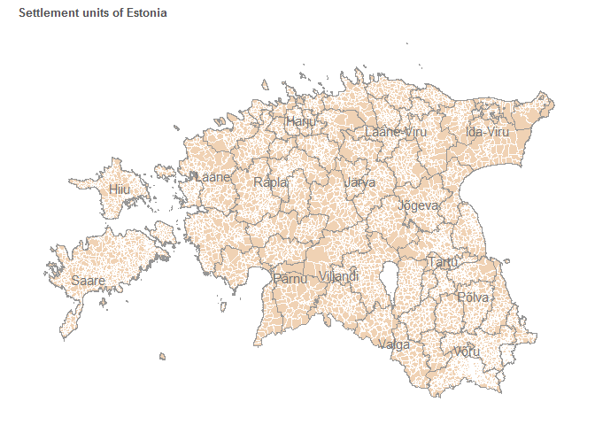

```r
settl_plot <-
  ggplot() +
  geom_sf(data = settl, fill = "#EABE94", color = "white", alpha = 0.7, size = 0.001) +
  geom_sf(data = munic, fill = NA, color = "#969696", size = 0.5) +
  geom_sf(data = count, fill = NA, color = "#969696", size = 1) +
  geom_sf_text(data = count, aes(label = str_sub(MNIMI, end = -8)), color = "#737373", size = 4) +
  labs(title = "Settlement units of Estonia") +
  theme_minimal() +
  theme(plot.title = element_text(face = "bold", color = "#525252", size = 10),
        panel.grid = element_blank(),
        panel.background = element_blank(),
        axis.title = element_blank(),
        axis.text = element_blank(),
        legend.position = "none")

pop_2019_plot <-
  ggplot() +
  geom_sf(data = pop_2019, aes(fill = VAARTUS), color = NA) +
  scale_fill_gradientn(colours = c("#ece2f0", "#a6bddb", "#3690c0", "#016c59", "#014636"), na.value = "#d9d9d9") +
  labs(fill = "Population number",
       title = "Population distribution in Estonia, 2019") +
  theme_minimal() +
  theme(plot.title = element_text(face = "bold", color = "#525252", size = 10),
        panel.grid = element_blank(),
        panel.background = element_blank(),
        axis.text = element_blank())
```

## 2.5 Settlement types

Settlements contain the information about type

Settlement type is coded by EHAK as follows:

0 - county  
1 - rural municipality  
3 - town  
4 - city  
5 - city without municipal status  
6 - city district  
7 - small town  
8 - village

Data source: Geoportal, Republic of Estonia LAND BOARD  
Geoportal

Check unique values of settlement types to see which types are represented in the dataset

```r
settl_types_UV <- unique(settl$TYYP)

cat(' The codes indicating the types of settlements of Estonia, are following:', sort(as.integer(settl_types_UV)))
```

```
##  The codes indicating the types of settlements of Estonia, are following: 3 4 5 6 7 8
```

Assign appropriate type names to EHAK codes in new fields called settl_type (urban & rural) and settl_hier (urban: big city, urban: small city, rural)

```r
# Settlement types
# Urban
urban <- settl$TYYP %in% c(3, 4, 5, 6, 7)
# Rural
rural <- settl$TYYP %in% c(8)
```

```r
# assign new values
settl$settl_type[urban] <- "urban"
settl$settl_type[rural] <- "rural"


settl$settl_hier <- settl$settl_type
settl$settl_hier <- ifelse(settl$settl_hier == 'urban', 'urban: small city', settl$settl_hier)


# Big cities: Tallinn, Tartu, Narva, Pärnu, Kohtla-Järve, Jõhvi
# Tallinn
settl$settl_hier <- ifelse(settl$ONIMI == 'Tallinn', 'urban: big city', settl$settl_hier)
# Tartu
settl$settl_hier <- ifelse(settl$ONIMI == 'Tartu linn' & settl$TYYP == '5', 'urban: big city', settl$settl_hier)
# Narva
settl$settl_hier <- ifelse(settl$ONIMI == 'Narva linn', 'urban: big city', settl$settl_hier)
# Pärnu
settl$settl_hier <- ifelse(settl$ONIMI == 'Pärnu linn' & settl$TYYP == '5', 'urban: big city', settl$settl_hier)
# Kohtla-Järve
settl$settl_hier <- ifelse(settl$ONIMI == 'Kohtla-Järve linn', 'urban: big city', settl$settl_hier)
# Jõhvi
settl$settl_hier <- ifelse(settl$ONIMI == 'Jõhvi vald' & settl$TYYP == '5', 'urban: big city', settl$settl_hier)
```

```r
# check newly assigned fields
head(settl, 1)
```

|  | ANIMI | AKOOD | TYYP | ONIMI | OKOOD | MNIMI | MKOOD | geometry | settl_type | settl_hier |
| --- | --- | --- | --- | --- | --- | --- | --- | --- | --- | --- |
| 1 | Väikeheinamaa küla / Lillängin | 9619 | 8 | Viimsi vald | 0890 | Harju maakond | 0037 |  | rural | rural |

Plot settlement types

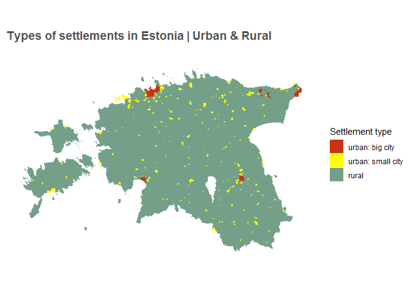

```r
settl_plot <-
  ggplot() +

  geom_sf(data = settl, aes(fill = settl_hier), color = NA, size = 0.1) +
  scale_fill_manual(breaks = c("urban: big city", "urban: small city", "rural"),
                    values = c("#C93312", "yellow", "#74A089")) +
  scale_color_manual(breaks = c("urban: big city", "urban: small city", "rural"),
                     values = c("black", "blue", "white")) +
  labs(fill = "Settlement type",
       title = "Types of settlements in Estonia | Urban & Rural") +
  theme_minimal() +
  theme(plot.title = element_text(face = "bold", color = "#525252", size = 14),
        panel.grid = element_blank(),
        panel.background = element_blank(),
        axis.text = element_blank())

settl_plot
```

# 3 Data preparation

## 3.1 Fix coordinates and rename columns

```r
# fix coordinates
mob_data <- mob_data %>%
  mutate(
    lon_x = as.character(lat) %>%
      str_pad(3, side = "left", pad = "0") %>%
      str_replace("(\\w{2})", "\\1\\.") %>%
      as.numeric(),
    lat_y = as.character(lon) %>%
      str_pad(3, side = "left", pad = "0") %>%
      str_replace("(\\w{2})", "\\1\\.") %>%
      as.numeric()
  )
```

To make dataset headers readable, it is better to change the names of the first and second users ‘op_pos_usr_id’ is replaced with ‘caller’ & ‘op_pos_usr_id_rec’ with ‘callee’

```r
# rename columns
colnames(mob_data)[which(names(mob_data) == 'op_pos_usr_id')] <- 'caller'
colnames(mob_data)[which(names(mob_data) == 'op_pos_usr_id_rec')] <- 'callee'
```

```r
# replace the user ID values for displaying
repl <- head(mob_data, 1)
repl$caller <- "xxxxxxxx"
repl$callee <- "xxxxxxxx"
repl
```

| caller | callee | pos_time | cell_id | site_id | lon | lat | lon_x | lat_y |
| --- | --- | --- | --- | --- | --- | --- | --- | --- |
| xxxxxxxx | xxxxxxxx | 2018-02-24 10:58:48 | 3066 | 829 | 593925055555556 | 281761166666667 | 28.17612 | 59.39251 |

## 3.2 Time variables

Create time variables

```r
# time variables
mob_data <- mob_data %>%
  mutate(
    year = year(pos_time),
    month = month(pos_time),
    day = day(pos_time),
    wday = lubridate::wday(pos_time, label = FALSE, week_start = getOption("lubridate.week.start", 1)),
    wday_attr = lubridate::wday(pos_time, label = TRUE, abbr = FALSE),
    hour = hour(pos_time),
    hour_rounded = hour(round_date(pos_time, "hour")),
    min = minute(pos_time),
    sec = second(pos_time),
    hour_min = hour + min/60
  )
```

Sort mobile data by user id (caller) and time

```r
mob_data <- mob_data[order(mob_data$caller, mob_data$pos_time), ]
```

```r
# replace the user ID values for displaying
repl <- head(mob_data, 1)
repl$caller <- "xxxxxxxx"
repl$callee <- "xxxxxxxx"
repl
```

| caller | callee | pos_time | cell_id | site_id | lon | lat | lon_x | lat_y | year | month | day | wday | wday_attr | hour | hour_rounded | min | sec | hour_min |
| --- | --- | --- | --- | --- | --- | --- | --- | --- | --- | --- | --- | --- | --- | --- | --- | --- | --- | --- |
| xxxxxxxx | xxxxxxxx | 2018-02-01 18:46:26 | 13906 | 451 | 589647833333333 | 229128444444444 | 22.91284 | 58.96478 | 2018 | 2 | 1 | 4 | Thursday | 18 | 19 | 46 | 26 | 18.76667 |

## 3.3 Join mobile dataset with settlement types

First, create x/y fields to use them for creating geometry and keep also them separately

```r
mob_data <- mob_data %>%
  mutate(x = lon_x,
         y = lat_y)
```

Convert data to sf format to use it later for joining

```r
mob_data_sf <- st_as_sf(mob_data, coords = c("x", "y"),  crs = 4326)  %>%
  st_transform(crs = 3301)
```

Join mobile data with settlement types by using st_join() and join = st_intersects for ‘point in polygon’ spatial relationship

```r
joined <- st_join(mob_data_sf, settl,
                  join = st_intersects,
                  left = TRUE)
```

Locate x/y from geometry into separate column by using unlist() and map()

```r
joined <- joined %>%
  mutate(x = unlist(map(joined$geometry, 1)),
         y = unlist(map(joined$geometry, 2)))
```

Drop the geometry column

```r
mob_data <- joined %>%
  st_drop_geometry()

class(mob_data)
```

```
## [1] "tbl_df"     "tbl"        "data.frame"
```

Backup the original dataset (mob_data) separately and use mob_data for analysis

```r
mob_data_bu <- mob_data
```

Check new variables

```r
# replace the user ID values for displaying
repl <- head(mob_data, 1)
repl$caller <- "xxxxxxxx"
repl$callee <- "xxxxxxxx"
repl
```

| caller | callee | pos_time | cell_id | site_id | lon | lat | lon_x | lat_y | year | month | day | wday | wday_attr | hour | hour_rounded | min | sec | hour_min | ANIMI | AKOOD | TYYP | ONIMI | OKOOD | MNIMI | MKOOD | settl_type | settl_hier | x | y |
| --- | --- | --- | --- | --- | --- | --- | --- | --- | --- | --- | --- | --- | --- | --- | --- | --- | --- | --- | --- | --- | --- | --- | --- | --- | --- | --- | --- | --- | --- |
| xxxxxxxx | xxxxxxxx | 2018-02-01 18:46:26 | 13906 | 451 | 589647833333333 | 229128444444444 | 22.91284 | 58.96478 | 2018 | 2 | 1 | 4 | Thursday | 18 | 19 | 46 | 26 | 18.76667 | Sääre küla | 7949 | 8 | Hiiumaa vald | 0205 | Hiiu maakond | 0039 | rural | rural | 437457.7 | 6536700 |

# 4 Distribution of calls

YEAR

```r
distr_year <-  mob_data %>%
  group_by(year) %>%
  summarise(n_calls = n()) %>%
  ungroup()

cat('The YEAR of mobile data distribution is:', as.character(unique(distr_year$year)))
```

```
## The YEAR of mobile data distribution is: 2018
```

MONTH

```r
distr_month <-  mob_data %>%
  group_by(month) %>%
  summarise(n_calls = n()) %>%
  ungroup()

cat('The MONTH of mobile data distribution is:', as.character(unique(unique(month(distr_month$month,label = TRUE, abbr = FALSE)))))
```

```
## The MONTH of mobile data distribution is: February
```

DAY

```r
distr_day <-  mob_data %>%
  group_by(day, wday, wday_attr) %>%
  summarise(n_calls = n()) %>%
  ungroup()

cat('The DAY of mobile data distribution is:', as.character(unique(distr_day$day)))
```

```
## The DAY of mobile data distribution is: 1 2 3 4 5 6 7 8 9 10 11 12 13 14 15 16 17 18 19 20 21 22 23 24 25 26 27 28
```

```r
cat('Total number of days:', nrow(distr_day))
```

```
## Total number of days: 28
```

Plot distribution of calls by days

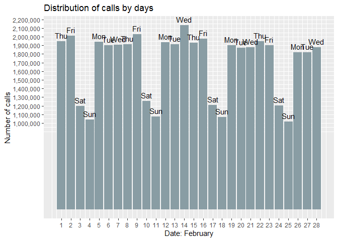

```r
distr_day_plot <-
  ggplot(data = distr_day,
         aes(x = day, y = n_calls)) +
  geom_bar(stat = "identity", fill = '#899DA4') +
  geom_text(aes(label = substr(wday_attr, 1, 3)), vjust = -0.5) +
  labs(title = 'Distribution of calls by days',
       x = 'Date: February',
       y = 'Number of calls') +
  scale_x_continuous(breaks = c(1, 2, 3, 4, 5, 6, 7, 8, 9, 10, 11, 12, 13, 14, 15, 16, 17, 18, 19, 20,
                                21, 22, 23, 24, 25, 26, 27, 28)) +
  scale_y_continuous(breaks = c(1000000, 1100000, 1200000, 1300000, 1400000, 1500000, 1600000, 1700000, 1800000, 1900000, 2000000,
                              2100000, 2200000),
                   labels = c('1,000,000', '1,100,000', '1,200,000', '1,300,000', '1,400,000', '1,500,000',
                              '1,600,000', '1,700,000', '1,800,000', '1,900,000', '2,000,000', '2,100,000', '2,200,000'))

distr_day_plot
```

Average number of daily calls

```r
distr_day_avr <-  distr_day %>%
  summarise(avr_calls = mean(n_calls))

cat('Average number of daily calls:', distr_day_avr$avr_calls)
```

```
## Average number of daily calls: 1701471
```

Average number of daily calls by workdays and weekends /nWorkdays

```r
# select working days
distr_day_working <- distr_day %>%
  filter(wday < 6 )

distr_day_working_avr <- distr_day_working %>%
  summarise(day = "Working days",
    avr_calls = mean(n_calls))

cat('Average number of daily calls during working days:', distr_day_working_avr$avr_calls)
```

```
## Average number of daily calls during working days: 1928493
```

Weekends

```r
# select weekends
distr_day_weekend <- distr_day %>%
  filter(wday > 5 )

distr_day_weekend_avr <- distr_day_weekend %>%
  summarise(day = "Weekends",
    avr_calls = mean(n_calls))

cat('Average number of daily calls during weekends:', distr_day_weekend_avr$avr_calls)
```

```
## Average number of daily calls during weekends: 1133917
```

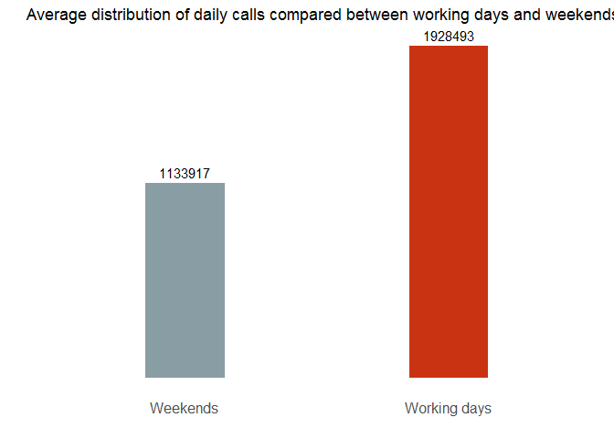

```r
distr_day_work_weekend_plot <-
  ggplot() +
  geom_bar(data = distr_day_working_avr, aes(x = day, y = avr_calls), stat = "identity", fill = '#C93312', width = 0.3) +
  geom_text(data = distr_day_working_avr, aes(x = day, y = avr_calls, label = round(avr_calls)), vjust = -0.5) +

  geom_bar(data = distr_day_weekend_avr, aes(x = day, y = avr_calls), stat = "identity", fill = '#899DA4', width = 0.3) +
  geom_text(data = distr_day_weekend_avr, aes(x = day, y = avr_calls, label = round(avr_calls)), vjust = -0.5) +

  labs(title = 'Average distribution of daily calls compared between working days and weekends',
       x = '',
       y = '') +
  theme(axis.text.x = element_text(size = 12),
        axis.text.y = element_blank(),
        axis.ticks = element_blank(),
        panel.background = element_blank())

distr_day_work_weekend_plot
```

Number of calls by users

[figure not shown]

```r
distr_day_caller <-  mob_data %>%
  group_by(caller, day, wday) %>%
  summarise(n_calls = n()) %>%
  ungroup()



distr_day_caller_plot <-
  ggplot(data = distr_day_caller, aes(y = n_calls)) +
  geom_boxplot(show.legend = FALSE) +
  facet_grid(~day, switch = "x") +
  ggtitle("Distribution of the number of Daily Calls by callers") +
  ylab("Number of calls") +
  scale_y_continuous(breaks = c(100, 500, 1000, 2000, 3000, 4000, 5000)) +
  theme_ipsum() +
  theme(
    axis.text.x = element_blank(),
    axis.ticks.x = element_blank()
  )

distr_day_caller_plot
```

Distribution of weekdays in the the dataset

```r
distr_wday <-  distr_day %>%
  group_by(wday_attr) %>%
  summarise(n_wdays = n()) %>%
  ungroup()


wdays <- gather(distr_wday,
       key = "wday_attr",
       value = "n_wdays")
wdays
```

| wday_attr | n_wdays |
| --- | --- |
| Sunday | 4 |
| Monday | 4 |
| Tuesday | 4 |
| Wednesday | 4 |
| Thursday | 4 |
| Friday | 4 |
| Saturday | 4 |

```r
unique(wdays$n_wdays)
```

```
## [1] 4
```

Distribution of calls by hours

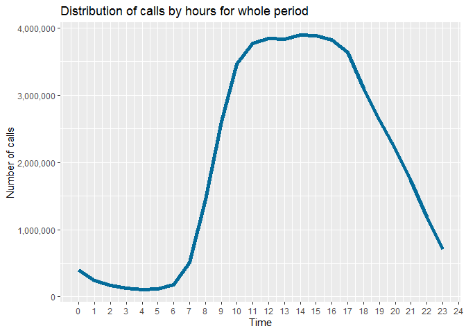

```r
calls_by_hours <-
  ggplot(data = mob_data %>%
           group_by(hour_rounded) %>%
           summarise(n_calls = n()) %>%
           ungroup(),
         aes(x = hour_rounded, y = n_calls)) +
  geom_line(size = 2, color = '#046C9A') +
  labs(title = 'Distribution of calls by hours for whole period',
       x = 'Time',
       y = 'Number of calls') +
  scale_x_continuous(breaks = c(0, 1, 2, 3, 4, 5, 6, 7, 8, 9, 10, 11, 12, 13, 14, 15, 16, 17, 18, 19, 20, 21, 22, 23, 24)) +
  scale_y_continuous(labels = comma)

calls_by_hours
```

Average distribution of calls by hours

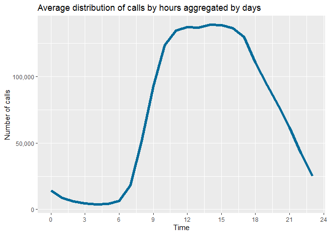

```r
calls_by_hours_avr <-
  ggplot(data = mob_data %>%
           group_by(day, hour_rounded) %>%
           summarise(n_calls = n()) %>%
           group_by(hour_rounded) %>%
           summarise(avr_calls = mean(n_calls)) %>%
           ungroup(),
         aes(x = hour_rounded, y = avr_calls)) +
  geom_line(size = 2, color = '#046C9A') +
  labs(title = 'Average distribution of calls by hours aggregated by days',
       x = 'Time',
       y = 'Number of calls') +
  scale_x_continuous(breaks = seq(0, 24, 3)) +
  scale_y_continuous(labels = comma)

calls_by_hours_avr
```

Distribution of calls by weekdays

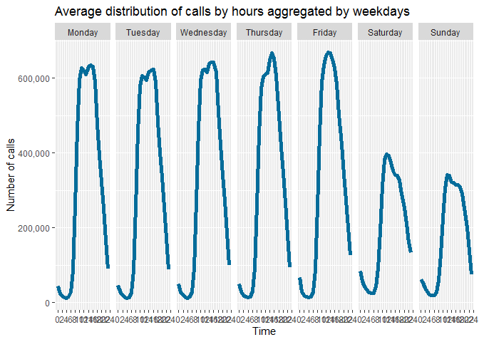

```r
calls_wday <-
  mob_data %>%
  group_by(wday_attr, hour_rounded) %>%
  summarise(n_calls = n()) %>%
  ungroup()

calls_wday$wday_attr <- factor(calls_wday$wday_attr, c("Monday", "Tuesday", "Wednesday", "Thursday", "Friday", "Saturday", "Sunday"))


calls_by_hours_wdays <-
  ggplot(data = calls_wday,
         aes(x = hour_rounded, y = n_calls, group = wday_attr)) +
  geom_line(size = 2, color = '#046C9A') +
  facet_grid(~wday_attr) +
  labs(title = 'Average distribution of calls by hours aggregated by weekdays',
       x = 'Time',
       y = 'Number of calls') +
  scale_x_continuous(breaks = seq(0, 24, 2)) +
  scale_y_continuous(labels = comma)

calls_by_hours_wdays
```

# 5 Filtering

## 5.1 Daily calls

Number of daily calls by callers to understand how many calls each user makes in a day

```r
daily_call_numb <- mob_data %>%
  group_by(caller, day) %>%
  summarise(n_calls = n())
```

Calculate median and mean of daily calls

```r
median_daily_calls <- median(daily_call_numb$n_calls)
mean_daily_calls <- mean(daily_call_numb$n_calls)

cat(' The median of daily calls made by callers:', median_daily_calls,
    '\n', 'The mean of daily calls made by callers:', round(mean_daily_calls, 1))
```

```
##  The median of daily calls made by callers: 3
##  The mean of daily calls made by callers: 5.1
```

Calculate percentiles of daily calls

```r
calls_percentiles <- quantile(daily_call_numb$n_calls, probs = c(0.25, 0.5, 0.9, 0.95, 0.99, 0.995, 0.999, 0.9995, 0.9999))
calls_prcnt <- quantile(daily_call_numb$n_calls, probs = c(0.9999))

cat('Percentiles of daily calls made by callers:', '\n')
```

```
## Percentiles of daily calls made by callers:
```

```r
calls_percentiles
```

```
##    25%    50%    90%    95%    99%  99.5%  99.9% 99.95% 99.99%
##      1      3     11     16     32     43     79    110    207
```

```r
calls_prcnt
```

```
## 99.99%
##    207
```

Draw histogram of daily calls

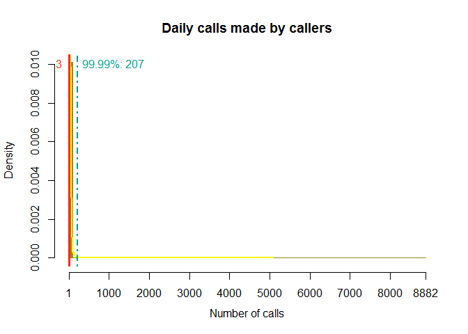

```r
hist(daily_call_numb$n_calls, probability = TRUE,
     main = 'Daily calls made by callers',
     xlab = 'Number of calls',
     xlim = c(1, 8882),
     col = '#9A8822',
     border = "#9A8822",
     breaks = c(1, 100, 500, 1000, 5000, 8000, 8882),
     xaxt = 'n')
axis(side = 1,
     at = c(1, 1000, 2000, 3000, 4000, 5000, 6000, 7000, 8000, 8882),
     labels = c(1, 1000, 2000, 3000, 4000, 5000, 6000, 7000, 8000, 8882),
     line = 0.5)
lines(density(daily_call_numb$n_calls), col = "yellow", lwd = 2)
abline(v = median(daily_call_numb$n_calls),
       col = "#F2300F",
       lwd = 3)
text(median(daily_call_numb$n_calls), y=0.01, as.character(median(daily_call_numb$n_calls)), pos = 2, col = "#F2300F")
abline(v = calls_prcnt,
       col = "#00A08A",
       lwd = 2,
       lty = 4)
text(calls_prcnt, y=0.01, "99.99%: 207", col = "#00A08A", pos = 2, offset = -5)
```

Draw histogram of daily calls with log10

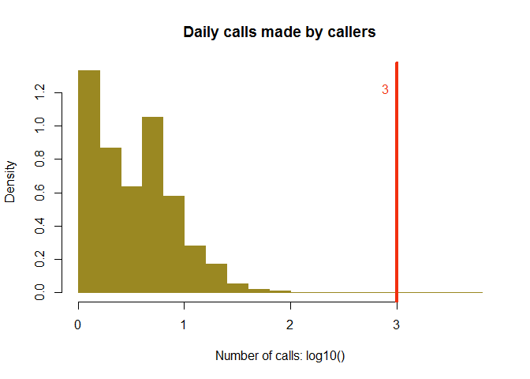

```r
hist(log10(daily_call_numb$n_calls), probability = TRUE,
     main = 'Daily calls made by callers',
     xlab = 'Number of calls: log10()',
     col = '#9A8822',
     border = "#9A8822")
abline(v = median(daily_call_numb$n_calls),
       col = "#F2300F",
       lwd = 4)
text(median(daily_call_numb$n_calls), y=1.22, as.character(median(daily_call_numb$n_calls)), pos = 2, col = "#F2300F")
```

```r
to_remove <- daily_call_numb %>%
  filter(n_calls >= 207)

# the number of observations that equals and fall over 207 score of daily calls equals 952 rows, that needs to be removed

daily_call_numb <- daily_call_numb %>%
  filter(n_calls < 207)
```

Draw histogram again

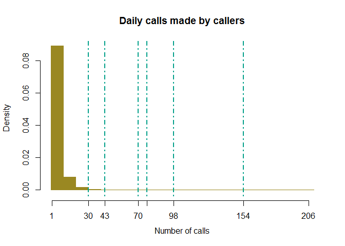

```r
hist(daily_call_numb$n_calls, probability = TRUE,
     main = 'Daily calls made by callers',
     xlab = 'Number of calls',
     col = '#9A8822',
     border = "#9A8822",
     xaxt = 'n')
axis(side = 1,
     at = c(1, 30, 43, 70, 77, 98, 154, 206),
     labels = c(1, 30, 43, 70, 77, 98, 154, 206),
     line = 0.5)
abline(v = quantile(daily_call_numb$n_calls, probs = c(0.989, 0.995, 0.9986, 0.999, 0.9995, 0.9999)),
       col = "#00A08A",
       lwd = 2,
       lty = 4)
text(quantile(daily_call_numb$n_calls, probs = c(0.989, 0.995, 0.9986, 0.999, 0.9995, 0.9999)),
     y=0.08, c("98.9%", "99.5%", "99.86%", "99.9%", "99.95%", "99.99%"), col = "#02401B", pos = 1, offset = -5)
```

```r
to_remove <- daily_call_numb %>%
  filter(n_calls >= 30)
# the number of observations that equals and fall over 70 score of daily calls equals 13,813 rows, that needs to be removed

daily_call_numb <- daily_call_numb %>%
  filter(n_calls < 30)
```

Plot the distribution of filtered dataset

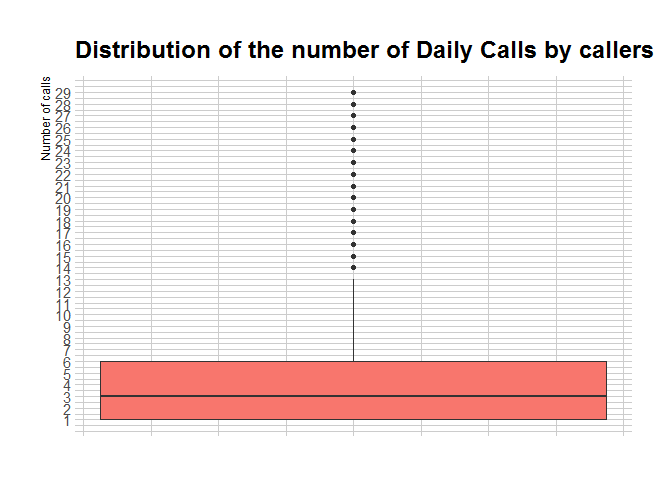

```r
daily_calls_boxplot <-
  ggplot(daily_call_numb, aes(y = n_calls, fill = "#FDDDA0")) +
  geom_boxplot(show.legend = FALSE) +
  ggtitle("Distribution of the number of Daily Calls by callers") +
  ylab("Number of calls") +
  scale_y_continuous(breaks = c(1, 2, 3, 4, 5, 6, 7, 8, 9, 10, 11, 12, 13, 14, 15, 16, 17, 18, 19, 20, 21, 22, 23, 24, 25, 26, 27, 28, 29)) +
  theme_ipsum() +
  theme(
    axis.text.x = element_blank(),
    axis.ticks.x = element_blank()
  )

daily_calls_boxplot
```

[figure not shown]

```r
daily_calls_days_boxplot <-
  ggplot(daily_call_numb, aes(y = n_calls, fill = "#FDDDA0")) +
  geom_boxplot(show.legend = FALSE) +
  facet_grid(~day, switch = "x") +
  ggtitle("Distribution of the number of Daily Calls by callers") +
  ylab("Number of calls") +
  scale_y_continuous(breaks = c(1, 2, 3, 4, 5, 6, 7, 8, 9, 10, 11, 12, 13, 14, 15, 16, 17, 18, 19, 20, 21, 22, 23, 24, 25, 26, 27, 28, 29)) +
  theme_ipsum() +
  theme(
    axis.text.x = element_blank(),
    axis.ticks.x = element_blank()
  )

daily_calls_days_boxplot
```

```r
# concatenate columns op_pos_usr_id_rec and day into new column user_day | then use new column to filter out
mob_data$user_day <- str_c(as.character(mob_data$caller), "-", as.character(mob_data$day))
daily_call_numb$user_day <- str_c(as.character(daily_call_numb$caller), "-", as.character(daily_call_numb$day))

# filter
mob_data <- mob_data %>%
  filter(mob_data$user_day %in% daily_call_numb$user_day)
```

## 5.2 Diurnal rhythm of calling activities

Draw histogram with ‘hour’ variable

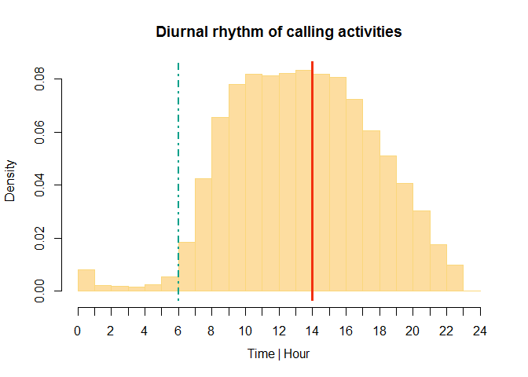

```r
par(lwd=0.01) # set line width
hist(mob_data$hour, probability = TRUE,
     main = 'Diurnal rhythm of calling activities',
     xlab = 'Time | Hour',
     xlim = c(0, 24),
     col = '#FDDDA0',
     border = "#FAD77B",
     breaks = c(0, 1, 2, 3, 4, 5, 6, 7, 8, 9, 10, 11, 12, 13, 14, 15, 16, 17, 18, 19, 20, 21, 22, 23, 24),
     xaxt = 'n')
axis(side = 1,
     at = c(0, 1, 2, 3, 4, 5, 6, 7, 8, 9, 10, 11, 12, 13, 14, 15, 16, 17, 18, 19, 20, 21, 22, 23, 24),
     labels = c(0, 1, 2, 3, 4, 5, 6, 7, 8, 9, 10, 11, 12, 13, 14, 15, 16, 17, 18, 19, 20, 21, 22, 23, 24),
     line = 0.5)
abline(v = median(mob_data$hour),
       col = "#F2300F",
       lwd = 3)
text(median(mob_data$hour), y=0.08, "Median", pos = 1, offset = -3, col = "black")

abline(v = quantile(mob_data$hour, probs = c(0.016)),
       col = "#00A08A",
       lwd = 2,
       lty = 4)
text(quantile(mob_data$hour, probs = c(0.016)), y=0.08, c("1.6%"),
     col = "black", pos = 1, offset = -3)
```

Draw histogram with ‘hour_rounded’ variable

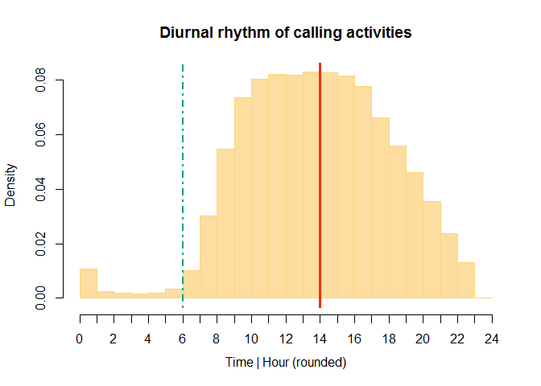

```r
par(lwd=0.01) # set line width
hist(mob_data$hour_rounded, probability = TRUE,
     main = 'Diurnal rhythm of calling activities',
     xlab = 'Time | Hour (rounded)',
     xlim = c(0, 24),
     col = '#FDDDA0',
     border = "#FAD77B",
     breaks = c(0, 1, 2, 3, 4, 5, 6, 7, 8, 9, 10, 11, 12, 13, 14, 15, 16, 17, 18, 19, 20, 21, 22, 23, 24),
     xaxt = 'n')
axis(side = 1,
     at = c(0, 1, 2, 3, 4, 5, 6, 7, 8, 9, 10, 11, 12, 13, 14, 15, 16, 17, 18, 19, 20, 21, 22, 23, 24),
     labels = c(0, 1, 2, 3, 4, 5, 6, 7, 8, 9, 10, 11, 12, 13, 14, 15, 16, 17, 18, 19, 20, 21, 22, 23, 24),
     line = 0.5)
abline(v = median(mob_data$hour_rounded),
       col = "#F2300F",
       lwd = 3)
text(median(mob_data$hour_rounded), y=0.079, "Median", pos = 1, offset = -3, col = "black")

abline(v = quantile(mob_data$hour_rounded, probs = c(0.02)),
       col = "#00A08A",
       lwd = 2,
       lty = 4)
text(quantile(mob_data$hour_rounded, probs = c(0.02)), y=0.079, c("2%"),
     col = "black", pos = 1, offset = -3)
```

Draw histogram with ‘hour_min’ variable

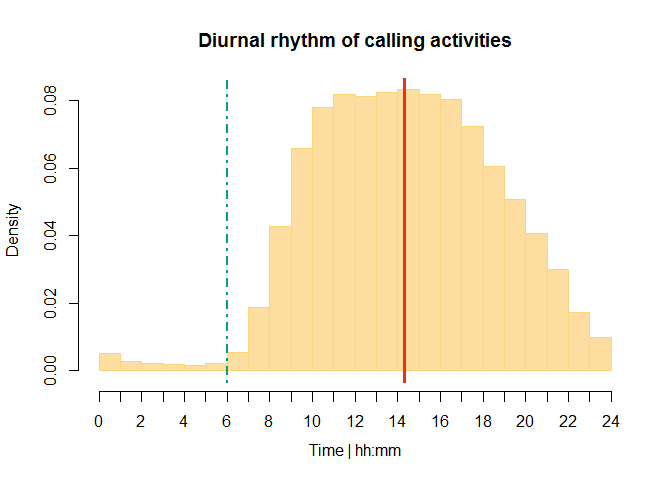

```r
par(lwd=0.01) # set line width
hist(mob_data$hour_min, probability = TRUE,
     main = 'Diurnal rhythm of calling activities',
     xlab = 'Time | hh:mm',
     xlim = c(0, 24),
     col = '#FDDDA0',
     border = "#FAD77B",
     breaks = c(0, 1, 2, 3, 4, 5, 6, 7, 8, 9, 10, 11, 12, 13, 14, 15, 16, 17, 18, 19, 20, 21, 22, 23, 24),
     xaxt = 'n')
axis(side = 1,
     at = c(0, 1, 2, 3, 4, 5, 6, 7, 8, 9, 10, 11, 12, 13, 14, 15, 16, 17, 18, 19, 20, 21, 22, 23, 24),
     labels = c(0, 1, 2, 3, 4, 5, 6, 7, 8, 9, 10, 11, 12, 13, 14, 15, 16, 17, 18, 19, 20, 21, 22, 23, 24),
     line = 0.5)
abline(v = median(mob_data$hour_min),
       col = "#F2300F",
       lwd = 3)
text(median(mob_data$hour_min), y=0.08, "Median", pos = 1, offset = -3, col = "black")

abline(v = quantile(mob_data$hour_min, probs = c(0.016)),
       col = "#00A08A",
       lwd = 2,
       lty = 4)
text(quantile(mob_data$hour_min, probs = c(0.016)), y=0.08, c("1.6%"),
     col = "black", pos = 1, offset = -3)
```

Remove the observations that occur after midnight till 6 AM

```r
# the number observations that falls under 6 AM
to_remove <- mob_data %>%
  filter(hour_min < 6)

mob_data <- mob_data %>%
  filter(hour_min >= 6)
```

```r
# In 'hour_rounded' variable, for midnight zero (0) is assigned. However, as I have removed all the variables under 6 AM, there is
# a gap between midnight and 6 AM, thus it is more reseanable to to give new value that is 24 to midnight instead of 0
mob_data$hour_rounded <- ifelse(mob_data$hour_rounded == 0, 24, mob_data$hour_rounded)
```

Aggregate data hours (rounded)

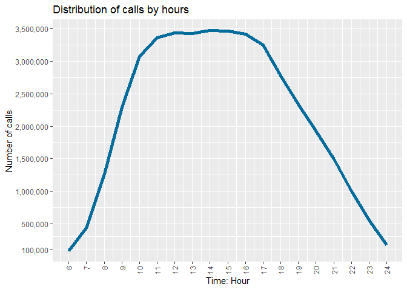

```r
hourly_calls_plot <-
  ggplot(data = mob_data %>%
         group_by(hour_rounded) %>%
         summarise(n_calls = n()) %>%
         ungroup(),
       aes(x = hour_rounded, y = n_calls)) +
  geom_line(size = 2, color = '#046C9A') +
  labs(title = 'Distribution of calls by hours',
       x = 'Time: Hour',
       y = 'Number of calls') +
  scale_x_continuous(breaks = c(6, 7, 8, 9, 10, 11, 12, 13, 14, 15, 16, 17, 18, 19, 20, 21, 22, 23, 24)) +
  scale_y_continuous(breaks = c(100000, 500000, 1000000, 1500000, 2000000, 2500000, 3000000, 3500000),
                   labels = comma) +
  theme(axis.text.x = element_text(angle = 90, vjust = 0.5, hjust = 1))

hourly_calls_plot
```

Aggregate data by weekday and hour (rounded)

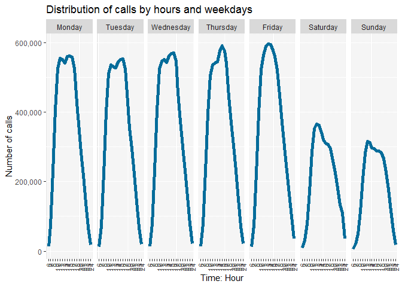

```r
hourly_calls_wday <- mob_data %>%
  group_by(wday_attr, hour_rounded) %>%
  summarise(n_calls = n()) %>%
  ungroup()


hourly_calls_wday$wday_attr <- factor(hourly_calls_wday$wday_attr, c("Monday", "Tuesday", "Wednesday", "Thursday", "Friday", "Saturday", "Sunday"))


hourly_calls_wday_plot <-
  ggplot(data = hourly_calls_wday,
         aes(x = hour_rounded, y = n_calls)) +
  geom_line(size = 2, color = '#046C9A') +
  facet_grid(~wday_attr) +
  labs(title = 'Distribution of calls by hours and weekdays',
       x = 'Time: Hour',
       y = 'Number of calls') +
  scale_x_continuous(breaks = c(6, 7, 8, 9, 10, 11, 12, 13, 14, 15, 16, 17, 18, 19, 20, 21, 22, 23, 24)) +
  scale_y_continuous(labels = comma) +
  theme(axis.text.x = element_text(angle = 90, vjust = 0.5, hjust = 1))

hourly_calls_wday_plot
```

# 6 Home locations

## 6.1 Filtering

Plot data with boxplot

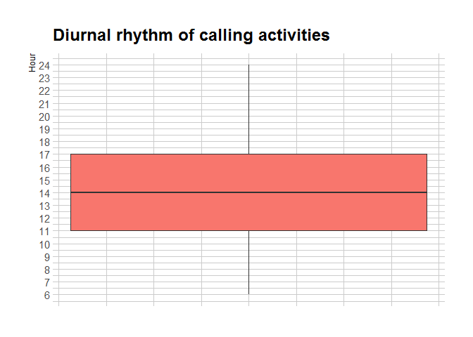

```r
# Concentration of calls by diurnal rhythm
diurnal_rhythm_plot <-
  ggplot(mob_data, aes(y = hour_rounded, fill = "#FDDDA0")) +
  geom_boxplot(show.legend = FALSE) +
  ggtitle("Diurnal rhythm of calling activities") +
  ylab("Hour") +
  scale_y_continuous(breaks = c(6, 7, 8, 9, 10, 11, 12, 13, 14, 15, 16, 17, 18, 19, 20, 21, 22, 23, 24)) +
  theme_ipsum() +
  theme(
    axis.text.x = element_blank(),
    axis.ticks.x = element_blank()
  )

diurnal_rhythm_plot
```

Observations that needs to me ecxluded

```r
to_remove <- mob_data %>%
  filter(hour_rounded >= 11 & hour_rounded <= 17)
```

Keep observations for which calls are made before 11 AM and 5 PM

```r
home_locations <- mob_data %>%
  filter(hour_rounded < 11 | hour_rounded > 17)
```

Check unique values of hours to make sure filtering results are correct

```r
sort(unique(home_locations$hour_rounded))
```

```
##  [1]  6  7  8  9 10 18 19 20 21 22 23 24
```

## 6.2 Aggregation

Aggregate ‘home_locations’ data by caller, antenna and day

```r
caller_antenna_day <- home_locations %>%
  group_by(caller, site_id, lon_x, lat_y, day) %>%
  summarise(n_calls = n()) %>%
  ungroup()
```

Aggregate ‘caller_antenna_day’ by caller and antenna so it is possible to count the frequency of days the caller has made the calls from the same antenna

```r
antenna_days <- caller_antenna_day %>%
  group_by(caller, site_id) %>%
  summarise(n_days = n()) %>%
  ungroup()
```

Calculate quantiles

```r
quantiles <- data.frame(quantiles_name = names(summary(antenna_days$n_days)),
                        quantiles_values = as.numeric(summary(antenna_days$n_days)))
quantiles_med_thirdq <- quantiles %>%
  filter(quantiles_name == 'Median' | quantiles_name == '3rd Qu.')
```

Plot frequency of days

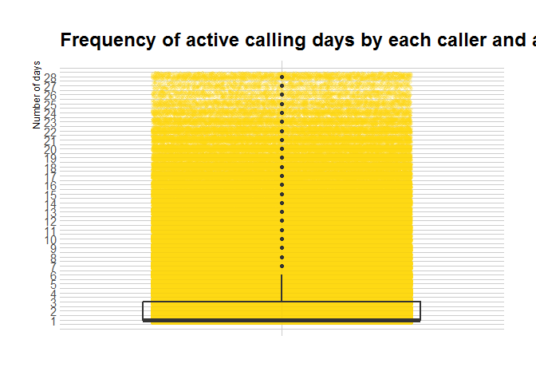

```r
day_freq <-
  ggplot(data = antenna_days, aes(x = "", y = n_days)) +



  geom_jitter(position = position_jitter(0.35),
              size = 1,
              colour= '#FAD510', alpha = 0.1,
              show.legend = FALSE) +

  geom_boxplot(lwd=1, fill = NA, alpha=0.8) +

  ggtitle("Frequency of active calling days by each caller and antenna") +
  ylab("Number of days") +
  scale_y_continuous(breaks = c(1, 2, 3, 4, 5, 6, 7, 8, 9, 10, 11, 12, 13, 14, 15, 16, 17, 18, 19, 20, 21, 22, 23, 24, 25, 26, 27, 28)) +
  theme_ipsum() +
  theme(
    axis.title.x = element_blank(),
    axis.ticks.x = element_blank(),
    legend.position = 'none'
  )


day_freq
```

```r
#ggsave('day_freq.png', units = 'cm', width = 40, height = 40)
```

50% of calls from the same antennas are made only for one day, 75% are made for three days. We can’t assume the antenna as home location if calling activitiy from it is made only once, twice or three times, as it contains the possibility of irregular, random call activity and not necessarily refer to frequent calling behaviour of the caller.

```r
to_remove <- antenna_days %>%
  filter(n_days < 4)

antenna_days <- antenna_days %>%
  filter(n_days > 3)
```

Now check from how many antennas the user has made calls (then choose the most frequent antennas)

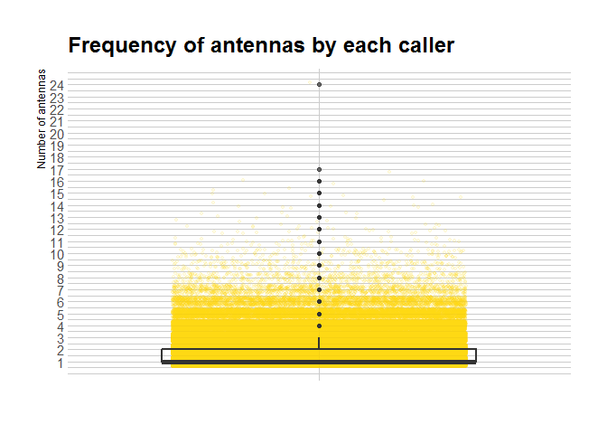

```r
# frequency of antennas by users
antenna_freq <- antenna_days %>%
  group_by(caller) %>%
  summarise(n_antennas = n()) %>%
  ungroup()

# plot frequency of antennas
antenna_freq_plot <-
  ggplot(data = antenna_freq, aes(x = "", y = n_antennas)) +

  geom_jitter(position = position_jitter(0.35),
              size = 1,
              colour= '#FAD510', alpha = 0.1,
              show.legend = FALSE) +

  geom_boxplot(lwd=1, fill = NA, alpha=0.7) +

  ggtitle("Frequency of antennas by each caller") +
  ylab("Number of antennas") +
  scale_y_continuous(breaks = c(1, 2, 3, 4, 5, 6, 7, 8, 9, 10, 11, 12, 13, 14, 15, 16, 17, 18, 19, 20, 21, 22, 23, 24)) +
  theme_ipsum() +
  theme(
    axis.title.x = element_blank(),
    axis.ticks.x = element_blank(),
    legend.position = 'bottom'
  )

antenna_freq_plot
```

```r
#ggsave('antenna_freq.png', units = 'cm', width = 40, height = 30)
```

Calculate quantiles

```r
quantile(antenna_freq$n_antennas, probs = c(0.25, 0.5, 0.75, 0.9, 0.95, 0.99, 0.995, 0.999, 0.9995, 0.9999))
```

```
##    25%    50%    75%    90%    95%    99%  99.5%  99.9% 99.95% 99.99%
##      1      1      2      3      4      6      7      9     10     12
```

Omit the users (callers) that have more than three frequent antennas

```r
to_remove <- antenna_freq %>%
  filter(n_antennas > 3)

antenna_freq <- antenna_freq %>%
  filter(n_antennas <=3)
```

Filter the caller IDs from ‘antenna_days’ dataset that matches caller IDs in ‘antenna_freq’ dataset, so now we would have caller id as well as antenna id

```r
antenna_days <- antenna_days %>%
  filter(antenna_days$caller %in% antenna_freq$caller)
```

Now filter the caller ID’s and site IDs from ‘home_locations’ dataset that matches ‘antenna_days’ dataset, so it is possible to count the number of calls from each frequent anntena and then select the antennas from which the most calls are made

```r
home_locations$user_antenna <- str_c(as.character(home_locations$caller), "-", as.character(home_locations$site_id))
antenna_days$user_antenna <- str_c(as.character(antenna_days$caller), "-", as.character(antenna_days$site_id))

home_locations <- home_locations %>%
  filter(home_locations$user_antenna %in% antenna_days$user_antenna)
```

Aggregate the ‘home_locations’ dataset by caller ID and site ID

```r
home_locations_ant <- home_locations %>%
  group_by(caller, site_id) %>%
  summarise(n_calls = n())
```

Order the dataset by caller ID and number of calls so for each unique user first would be antenna/site ID with the most number of calls

```r
home_locations_ant <- home_locations_ant[order(home_locations_ant$caller, -home_locations_ant$n_calls),]

home_locations_ant <- home_locations_ant[!duplicated(home_locations_ant$caller),]


home_locations_ant$user_antenna <- str_c(as.character(home_locations_ant$caller), "-", as.character(home_locations_ant$site_id))
```

Select the caller IDs and antena IDs from the main, ‘mob_data’ dataset that matches ‘home_locations_ant’ (which contains home locations)

```r
mob_data$user_antenna <- str_c(as.character(mob_data$caller), "-", as.character(mob_data$site_id))

mob_data_home <- mob_data %>%
  filter(mob_data$user_antenna %in% home_locations_ant$user_antenna)
```

Number of unique callers

```r
callers <- mob_data_home %>%
  group_by(caller) %>%
  summarise(n_call = n()) %>%
  ungroup()

cat(' The number of unique callers:', as.character(count(callers)))
```

```
##  The number of unique callers: 350499
```

Number of unique callees

```r
callees <-  mob_data_home %>%
  group_by(callee) %>%
  summarise(n_call = n()) %>%
  ungroup()

cat(' The number of unique callees:', as.character(count(callees)))
```

```
##  The number of unique callees: 1208110
```

Now check how many users are in among both, callers and callees

```r
common_users <- callers %>%
  filter(callers$caller %in% callees$callee)

# check with opposite
common_users1 <- callees %>%
  filter(callees$callee %in% callers$caller)

cat(' The number of common users (among both, caller and callees):', as.character(count(common_users)))
```

```
##  The number of common users (among both, caller and callees): 320497
```

Merge common_users dataset with mob_data_home dataset

```r
common_users <- common_users %>%
  mutate(id = caller) %>%
  select(id)

common_users <- merge(common_users, mob_data_home, by.x = 'id', by.y = 'caller')

common_users <- common_users %>%
  mutate(xx = lon_x,
         yy = lat_y,
         lon = x,
         lat = y,
         settl1 = settl_type,
         settl2 = settl_hier) %>%
  select(id, xx, yy, lon, lat, settl1, settl2) %>%
  group_by(id, xx, yy, lon, lat, settl1, settl2) %>%
  summarise(n = n()) %>%
  select(id, xx, yy, lon, lat, settl1, settl2)



mob_data_home <- mob_data_home %>%
  mutate(id = callee)
common_users <- common_users %>%
  mutate(callee_id = id)

mob_data_home <- merge(mob_data_home, common_users, by.x = 'id', by.y = 'id', all = FALSE)


mob_data_home <- mob_data_home %>%
  mutate(ox = lon_x,
         oy = lat_y,
         dx = xx,
         dy = yy,
         o_lon = x,
         o_lat = y,
         d_lon = lon.y,
         d_lat = lat.y,
         o_settl_type = settl_type,
         o_settl_hier = settl_hier,
         d_settl_type = settl1,
         d_settl_hier = settl2)
```

Calculate distance between call pairs

```r
mob_data_home <- mob_data_home %>%
  rowwise() %>%
  mutate(dist_km = distm(c(ox, oy), c(dx, dy), fun = distHaversine)/1000)
```

Social networks dataset

```r
soc_net <- mob_data_home

#replace the user ID values for displaying
repl <- head(soc_net, 1)
repl$caller <- "xxxxxxxx"
repl$callee <- "xxxxxxxx"
repl
```

| id | caller | callee | pos_time | cell_id | site_id | lon.x | lat.x | lon_x | lat_y | year | month | day | wday | wday_attr | hour | hour_rounded | min | sec | hour_min | ANIMI | AKOOD | TYYP | ONIMI | OKOOD | MNIMI | MKOOD | settl_type | settl_hier | x | … |
| --- | --- | --- | --- | --- | --- | --- | --- | --- | --- | --- | --- | --- | --- | --- | --- | --- | --- | --- | --- | --- | --- | --- | --- | --- | --- | --- | --- | --- | --- | --- |
| 12098709 | xxxxxxxx | xxxxxxxx | 2018-02-11 18:10:15 | 6325 | 180 | 589925 | 2272195 | 22.72195 | 58.9925 | 2018 | 2 | 11 | 7 | Sunday | 18 | 18 | 10 | 15 | 18.16667 | Kärdla linn | 3895 | 5 | Hiiumaa vald | 0205 | Hiiu maakond | 0039 | urban | urban: small city | 426536 | … |

Number of unique callers

```r
soc_net_callers <- soc_net %>%
  group_by(caller) %>%
  summarise(n_calls = n()) %>%
  ungroup()
```

Number of unique callees

```r
soc_net_callees <- soc_net %>%
  group_by(callee) %>%
  summarise(n_calls = n()) %>%
  ungroup()
```

Number of unique call pairs

```r
soc_net_call_pairs <- soc_net %>%
  group_by(caller, callee) %>%
  summarise(n_calls = n()) %>%
  ungroup()

max(soc_net$dist_km)
```

```
## [1] 375.5843
```

Draw histogram to see the distribution of distance between call pairs

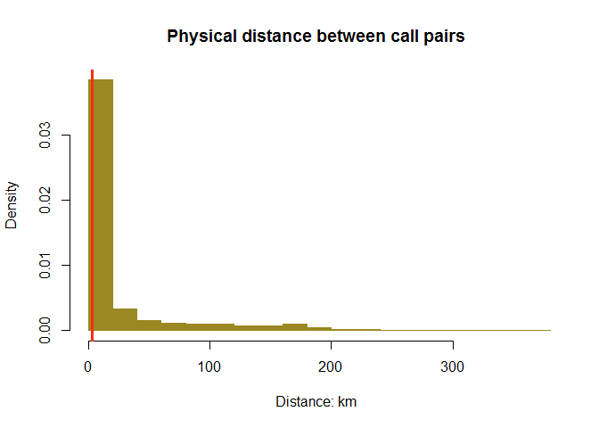

```r
hist(soc_net$dist_km, probability = TRUE,
     main = 'Physical distance between call pairs',
     xlab = 'Distance: km',
     xlim = c(0, 375.5843),
     col = '#9A8822',
     border = "#9A8822")
abline(v = median(soc_net$dist_km),
       col = "#F2300F",
       lwd = 3)
text(median(soc_net$dist_km), y=0.03, as.character(round(median(soc_net$dist_km), 2)), pos = 1, offset = -5, col = "black")
```

Create new field that represents the settlement types between call pairs

```r
soc_net$settl_type_pairs <- str_c(soc_net$o_settl_type, " - ", soc_net$d_settl_type)
soc_net$settl_hier_pairs <- str_c(soc_net$o_settl_hier, " - ", soc_net$d_settl_hier)
```

Now the social network dataset is ready for network analysis.

# 7 Network analysis

## 7.1 Data preparation for creating a graph

Select particular columns

```r
soc_net_sel <- soc_net %>%
  select(caller, callee, o_settl_type, o_settl_hier, d_settl_type, d_settl_hier, ox, oy, dx, dy, o_lon, o_lat, d_lon, d_lat, dist_km, settl_type_pairs, settl_hier_pairs, wday, wday_attr)
```

Create dataset of Edges

```r
# edgelist with not aggregated data
edgelist <- soc_net_sel %>%
  select(caller, callee, dist_km, settl_type_pairs, settl_hier_pairs, wday, wday_attr) %>%
  mutate(dist_km_nr = dist_km,
         dist_km = round(dist_km, 1))

colnames(edgelist)[which(names(edgelist) == 'caller')] <- 'Source'
colnames(edgelist)[which(names(edgelist) == 'callee')] <- 'Target'

edgelist <- edgelist %>%
  mutate(Source = as.character(Source),
         Target = as.character(Target))
```

Aggregate edges

```r
edge_weight <- edgelist %>%
  group_by(Source, Target, dist_km, settl_type_pairs, settl_hier_pairs) %>%
  summarise(weight = n()) %>%
  ungroup()

# aggregate call pairs according to weekdays
wdays <- edgelist %>%
  group_by(Source, Target, wday, wday_attr) %>%
  summarise(weight_wd = n()) %>%
  ungroup()


wdays$st <- str_c(as.character(wdays$Source), "-", as.character(wdays$Target))

wdays <- wdays %>%
  select(st, wday, weight_wd)

wdays <- wdays %>%
  spread(wday, weight_wd)


edgelist$st <- str_c(as.character(edgelist$Source), "-", as.character(edgelist$Target))
edge_weight$st <- str_c(as.character(edge_weight$Source), "-", as.character(edge_weight$Target))


edge_weight <- edge_weight %>%
  mutate(dist_km_nr = edgelist$dist_km_nr[match(st, edgelist$st)])


edge_weight <- edge_weight %>%
  mutate(weight_mon = as.numeric(wdays$`1`[match(st, wdays$st)]),
         weight_tues = as.numeric(wdays$`2`[match(st, wdays$st)]),
         weight_wed = as.numeric(wdays$`3`[match(st, wdays$st)]),
         weight_thur = as.numeric(wdays$`4`[match(st, wdays$st)]),
         weight_fri = as.numeric(wdays$`5`[match(st, wdays$st)]),
         weight_sat = as.numeric(wdays$`6`[match(st, wdays$st)]),
         weight_sun = as.numeric(wdays$`7`[match(st, wdays$st)])) %>%
  replace(is.na(.), 0)


workdays <- data.frame(edge_weight$weight_mon, edge_weight$weight_tues, edge_weight$weight_wed, edge_weight$weight_thur, edge_weight$weight_fri)
weekends <- data.frame(edge_weight$weight_sat, edge_weight$weight_sun)

edge_weight <- edge_weight %>%
   mutate(weight_workdays = rowSums(workdays),
         weight_weekends = rowSums(weekends))

glimpse(edge_weight)
```

```
## Rows: 1,667,294
## Columns: 17
## $ Source           <chr> "12098709", "12098709", "12098709", "12184335", "1218~
## $ Target           <chr> "16587961", "16600218", "16708885", "16544300", "1655~
## $ dist_km          <dbl[,1]> <matrix[26 x 1]>
## $ settl_type_pairs <chr> "rural - rural", "rural - rural", "rural - urban"~
## $ settl_hier_pairs <chr> "rural - rural", "rural - rural", "rural - urban: sma~
## $ weight           <int> 1, 1, 3, 3, 1, 2, 1, 7, 4, 1, 1, 1, 1, 2, 2, 1, 1, 6,~
## $ st               <chr> "12098709-16587961", "12098709-16600218", "12098709-1~
## $ dist_km_nr       <dbl> 0.000000, 0.000000, 11.377817, 72.197525, 4.203883, 4~
## $ weight_mon       <dbl> 0, 0, 0, 0, 1, 0, 0, 2, 0, 0, 0, 0, 0, 0, 0, 0, 0, 0,~
## $ weight_tues      <dbl> 0, 0, 0, 0, 0, 0, 0, 0, 1, 0, 0, 0, 0, 0, 1, 1, 1, 1,~
## $ weight_wed       <dbl> 0, 0, 1, 0, 0, 1, 1, 5, 1, 0, 1, 0, 0, 0, 0, 0, 0, 3,~
## $ weight_thur      <dbl> 0, 0, 0, 0, 0, 0, 0, 0, 0, 1, 0, 0, 0, 0, 0, 0, 0, 1,~
## $ weight_fri       <dbl> 1, 1, 1, 3, 0, 1, 0, 0, 0, 0, 0, 1, 1, 0, 1, 0, 0, 1,~
## $ weight_sat       <dbl> 0, 0, 1, 0, 0, 0, 0, 0, 1, 0, 0, 0, 0, 2, 0, 0, 0, 0,~
## $ weight_sun       <dbl> 0, 0, 0, 0, 0, 0, 0, 0, 1, 0, 0, 0, 0, 0, 0, 0, 0, 0,~
## $ weight_workdays  <dbl> 1, 1, 2, 3, 1, 2, 1, 7, 2, 1, 1, 1, 1, 0, 2, 1, 1, 6,~
## $ weight_weekends  <dbl> 0, 0, 1, 0, 0, 0, 0, 0, 2, 0, 0, 0, 0, 2, 0, 0, 0, 0,~
```

```r
edge_weight <- edge_weight %>%
  mutate(weight = as.numeric(weight))
```

Create dataset of Nodes

```r
# select callers as nodes
nodes1 <- soc_net_sel %>%
  select(caller, o_settl_type, o_settl_hier, ox, oy, o_lon, o_lat)

colnames(nodes1)[which(names(nodes1) == 'caller')] <- 'ID'
colnames(nodes1)[which(names(nodes1) == 'o_settl_type')] <- 'settl_type'
colnames(nodes1)[which(names(nodes1) == 'o_settl_hier')] <- 'settl_hier'
colnames(nodes1)[which(names(nodes1) == 'ox')] <- 'x'
colnames(nodes1)[which(names(nodes1) == 'oy')] <- 'y'
colnames(nodes1)[which(names(nodes1) == 'o_lon')] <- 'lon'
colnames(nodes1)[which(names(nodes1) == 'o_lat')] <- 'lat'


# select callees as nodes
nodes2 <- soc_net_sel %>%
  select(callee, d_settl_type, d_settl_hier, dx, dy, d_lon, d_lat)

colnames(nodes2)[which(names(nodes2) == 'callee')] <- 'ID'
colnames(nodes2)[which(names(nodes2) == 'd_settl_type')] <- 'settl_type'
colnames(nodes2)[which(names(nodes2) == 'd_settl_hier')] <- 'settl_hier'
colnames(nodes2)[which(names(nodes2) == 'dx')] <- 'x'
colnames(nodes2)[which(names(nodes2) == 'dy')] <- 'y'
colnames(nodes2)[which(names(nodes2) == 'd_lon')] <- 'lon'
colnames(nodes2)[which(names(nodes2) == 'd_lat')] <- 'lat'

# bind both nodes (caller & callees)
nodes <- rbind(nodes1, nodes2)

nodes <- nodes %>%
  group_by(ID, settl_type, settl_hier, x, y, lon, lat) %>%
  summarise(n = n()) %>%
  select(ID, settl_type, settl_hier, x, y, lon, lat)
```

Export the edgelist and nodes datasets

```r
# save csv
#write_csv(edgelist, 'Data\\working\\edgelist.csv')
#write_csv(nodes, 'Data\\working\\nodes.csv')
```

Simple stats

```r
min(edge_weight$weight)
```

```
## [1] 1
```

```r
max(edge_weight$weight)
```

```
## [1] 532
```

```r
round(mean(edge_weight$weight), 2)
```

```
## [1] 3.78
```

```r
median(edge_weight$weight)
```

```
## [1] 2
```

```r
quantile(edge_weight$weight, probs = c(0.25, 0.5, 0.75, 0.9, 0.95, 0.99, 0.995, 0.999, 0.9995, 0.9999))
```

```
##    25%    50%    75%    90%    95%    99%  99.5%  99.9% 99.95% 99.99%
##      1      2      4      8     14     33     45     82    101    156
```

## 7.2 Create a graph

Create matrix

```r
sn_edges <- edge_weight %>%
  select(Source, Target)

sn.mat <- as.matrix(sn_edges)
```

Create graph

```r
sn_g <- graph.edgelist(sn.mat, directed = TRUE)

#V(sn_g)
#E(sn_g)
```

```r
# Count number of edges
gsize(sn_g)
```

```
## [1] 1667294
```

```r
# Count number of vertiices
gorder(sn_g)
```

```
## [1] 332698
```

Give attributes to nodes

```r
settl_type <- nodes$settl_type
settl_hier <- nodes$settl_hier
x <- nodes$x
y <- nodes$y
lon <- nodes$lon
lat <- nodes$lat

# create new vertex attributes
sn_g <- set_vertex_attr(sn_g, 'settl_type', value = settl_type)
sn_g <- set_vertex_attr(sn_g, 'settl_hier', value = settl_hier)
sn_g <- set_vertex_attr(sn_g, 'x', value = x)
sn_g <- set_vertex_attr(sn_g, 'y', value = y)
sn_g <- set_vertex_attr(sn_g, 'lon', value = lon)
sn_g <- set_vertex_attr(sn_g, 'lat', value = lat)
```

Give attributes to links

```r
dist_km <- edge_weight$dist_km
settl_type_pairs <- edge_weight$settl_type_pairs
settl_hier_pairs <- edge_weight$settl_hier_pairs
weight <- edge_weight$weight

# create edge attributes
sn_g <- set_edge_attr(sn_g, 'dist_km', value = dist_km)
sn_g <- set_edge_attr(sn_g, 'settl_type_pairs', value = settl_type_pairs)
sn_g <- set_edge_attr(sn_g, 'settl_hier_pairs', value = settl_hier_pairs)
sn_g <- set_edge_attr(sn_g, 'weight', value = weight)
```

```r
class(sn_g)
```

```
## [1] "igraph"
```

```r
# View all vertex attributes in a list
#vertex_attr(sn_g)
```

```r
# View attributes of first five vertices in a dataframe
#V(sn_g)[[1:5]]
```

```r
# View edge attributes of graph object
#edge_attr(sn_g)
```

```r
# View attributes of first five edges in a dataframe
#E(sn_g)[[1:5]]
```

```r
# Find all pairs that has less than 50 km physical distance
#E(sn_g)[[dist_km<50]]
```

```r
# Different way to create graph from dataframe
#s_net <- graph_from_data_frame(d = edge_weight, vertices = nodes, directed = T)
#s_net <- simplify(s_net, remove.loops = T)
# combine multiple edges by summing their weights
#s_net <- simplify(s_net, edge.attr.comb = list(weight = "sum"))
#test <- as_data_frame(s_net, what = "edges")
#class(s_net) #
```

# 8 Node degrees

Function degree() has: ‘in-degree’, ‘out-degree’ and ‘all’ or ‘total’ modes

```r
# Calculate node degree with modes: all, in, out
V(sn_g)$degree <- igraph::degree(sn_g, mode = "all")
V(sn_g)$degree_in <- igraph::degree(sn_g, mode = "in")
V(sn_g)$degree_out <- igraph::degree(sn_g, mode = "out")
```

```r
# Subgraphs according to settlement types
sn_g_urb_bigcity <- induced_subgraph(sn_g, V(sn_g)[settl_hier=='urban: big city'])
sn_g_urb_smallcity <- induced_subgraph(sn_g, V(sn_g)[settl_hier=='urban: small city'])
sn_g_rural <- induced_subgraph(sn_g, V(sn_g)[settl_hier=='rural'])
```

Plot node degree distribution

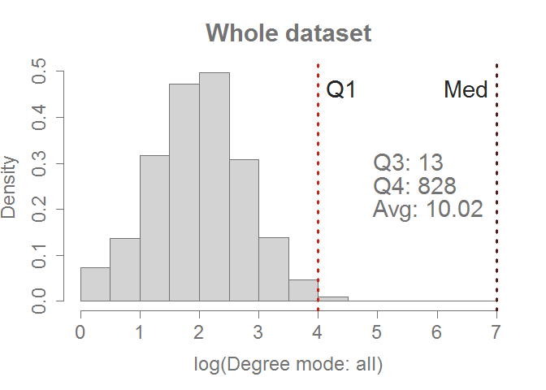

```r
#dev.cur()
#dev.off()

# All

#png("Figures\\test.png", width = 40, height = 25, units = "cm", res = 300)
#par(mfrow=c(2,2))

hist(log(V(sn_g)$degree),
     probability = TRUE,
     main = "Whole dataset",
     xlab = 'log(Degree mode: all)',
     border = "#737373",
     col.main = "#737373",
     col.lab = "#737373",
     cex.main = 1.9,
     cex.lab = 1.5,
     xaxt = 'n',
     yaxt = 'n'
     )
axis(1,
     col = "#737373",
     col.ticks = "#737373",
     col.axis = "#737373",
     cex.axis = 1.5)
axis(2,
     col = "#737373",
     col.ticks = "#737373",
     col.axis = "#737373",
     cex.axis = 1.5)
abline(v = median(V(sn_g)$degree),
       col = "#5B1A18",
       lwd = 3,
       lty = 3)
text(median(V(sn_g)$degree), y=0.46, "Med", pos = 2, col = "#252525", cex = 1.8)
abline(v =quantile(V(sn_g)$degree, probs = 0.25),
       col = "#CB2314",
       lwd = 3,
       lty = 3)
text(quantile(V(sn_g)$degree, probs = 0.25), y=0.46, "Q1", pos = 4, col = "#252525", cex = 1.8)

q3 <- str_c("Q3", ": ", quantile(V(sn_g)$degree, probs = 0.75))
text(x=4.8, y=0.3, q3, pos = 4, col = "#737373", cex = 1.8)

q4 <- str_c("Q4", ": ", quantile(V(sn_g)$degree, probs = 1))
text(x=4.8, y=0.25, q4, pos = 4, col = "#737373", cex = 1.8)

avg_deg <- str_c("Avg", ": ", round(mean(V(sn_g)$degree), 2))
text(x=4.8, y=0.2, avg_deg, pos = 4, col = "#737373", cex = 1.8)
```

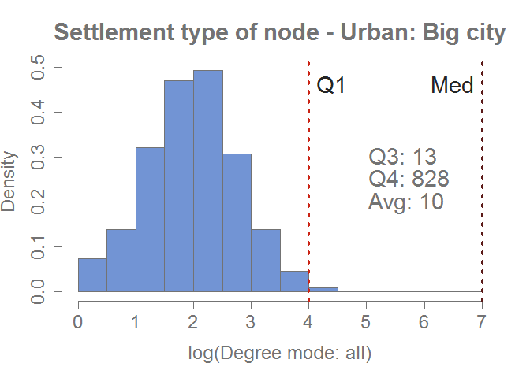

```r
# Urban: Big City
hist(log(V(sn_g_urb_bigcity)$degree),
     probability = TRUE,
     main = "Settlement type of node - Urban: Big city",
     xlab = 'log(Degree mode: all)',
     col = "#7294D4",
     border = "#737373",
     col.main = "#737373",
     col.lab = "#737373",
     cex.main = 1.9,
     cex.lab = 1.5,
     xaxt = 'n',
     yaxt = 'n'
     )
axis(1,
     col = "#737373",
     col.ticks = "#737373",
     col.axis = "#737373",
     cex.axis = 1.5)
axis(2,
     col = "#737373",
     col.ticks = "#737373",
     col.axis = "#737373",
     cex.axis = 1.5)
abline(v = median(V(sn_g_urb_bigcity)$degree),
       col = "#5B1A18",
       lwd = 3,
       lty = 3)
text(median(V(sn_g_urb_bigcity)$degree), y=0.46, "Med", pos = 2, col = "#252525", cex = 1.8)
abline(v =quantile(V(sn_g_urb_bigcity)$degree, probs = 0.25),
       col = "#CB2314",
       lwd = 3,
       lty = 3)
text(quantile(V(sn_g_urb_bigcity)$degree, probs = 0.25), y=0.46, "Q1", pos = 4, col = "#252525", cex = 1.8)

q3 <- str_c("Q3", ": ", quantile(V(sn_g_urb_bigcity)$degree, probs = 0.75))
text(x=4.9, y=0.3, q3, pos = 4, col = "#737373", cex = 1.8)

q4 <- str_c("Q4", ": ", quantile(V(sn_g_urb_bigcity)$degree, probs = 1))
text(x=4.9, y=0.25, q4, pos = 4, col = "#737373", cex = 1.8)

avg_deg <- str_c("Avg", ": ", round(mean(V(sn_g_urb_bigcity)$degree), 2))
text(x=4.9, y=0.2, avg_deg, pos = 4, col = "#737373", cex = 1.8)
```

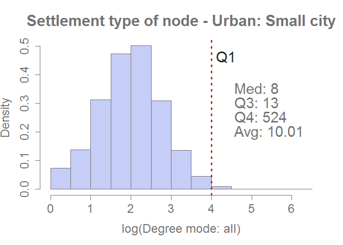

```r
# Urban: Small city
hist(log(V(sn_g_urb_smallcity)$degree),
     probability = TRUE,
     main = "Settlement type of node - Urban: Small city",
     xlab = 'log(Degree mode: all)',
     col = "#C6CDF7",
     border = "#737373",
     col.main = "#737373",
     col.lab = "#737373",
     cex.main = 1.9,
     cex.lab = 1.5,
     xaxt = 'n',
     yaxt = 'n'
     )
axis(1,
     col = "#737373",
     col.ticks = "#737373",
     col.axis = "#737373",
     cex.axis = 1.5)
axis(2,
     col = "#737373",
     col.ticks = "#737373",
     col.axis = "#737373",
     cex.axis = 1.5)
abline(v =quantile(V(sn_g_urb_smallcity)$degree, probs = 0.25),
       col = "#CB2314",
       lwd = 3,
       lty = 3)
text(quantile(V(sn_g_urb_smallcity)$degree, probs = 0.25), y=0.46, "Q1", pos = 4, col = "#252525", cex = 1.8)

med <- str_c("Med", ": ", median(V(sn_g_urb_smallcity)$degree))
text(x=4.45, y=0.35, med, pos = 4, col = "#737373", cex = 1.8)

q3 <- str_c("Q3", ": ", quantile(V(sn_g_urb_smallcity)$degree, probs = 0.75))
text(x=4.45, y=0.3, q3, pos = 4, col = "#737373", cex = 1.8)

q4 <- str_c("Q4", ": ", quantile(V(sn_g_urb_smallcity)$degree, probs = 1))
text(x=4.45, y=0.25, q4, pos = 4, col = "#737373", cex = 1.8)

avg_deg <- str_c("Avg", ": ", round(mean(V(sn_g_urb_smallcity)$degree), 2))
text(x=4.45, y=0.2, avg_deg, pos = 4, col = "#737373", cex = 1.8)
```

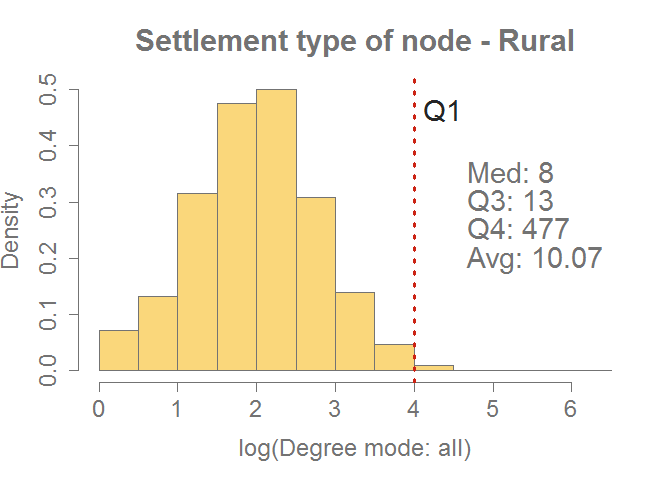

```r
# Rural
hist(log(V(sn_g_rural)$degree),
     probability = TRUE,
     main = "Settlement type of node - Rural",
     xlab = 'log(Degree mode: all)',
     col = "#FAD77B",
     border = "#737373",
     col.main = "#737373",
     col.lab = "#737373",
     cex.main = 1.9,
     cex.lab = 1.5,
     xaxt = 'n',
     yaxt = 'n'
     )
axis(1,
     col = "#737373",
     col.ticks = "#737373",
     col.axis = "#737373",
     cex.axis = 1.5)
axis(2,
     col = "#737373",
     col.ticks = "#737373",
     col.axis = "#737373",
     cex.axis = 1.5)
abline(v =quantile(V(sn_g_rural)$degree, probs = 0.25),
       col = "#CB2314",
       lwd = 3,
       lty = 3)
text(quantile(V(sn_g_rural)$degree, probs = 0.25), y=0.46, "Q1", pos = 4, col = "#252525", cex = 1.8)

med <- str_c("Med", ": ", median(V(sn_g_rural)$degree))
text(x=4.55, y=0.35, med, pos = 4, col = "#737373", cex = 1.8)

q3 <- str_c("Q3", ": ", quantile(V(sn_g_rural)$degree, probs = 0.75))
text(x=4.55, y=0.3, q3, pos = 4, col = "#737373", cex = 1.8)


q4 <- str_c("Q4", ": ", quantile(V(sn_g_rural)$degree, probs = 1))
text(x=4.55, y=0.25, q4, pos = 4, col = "#737373", cex = 1.8)

avg_deg <- str_c("Avg", ": ", round(mean(V(sn_g_rural)$degree), 2))
text(x=4.55, y=0.2, avg_deg, pos = 4, col = "#737373", cex = 1.8)
```

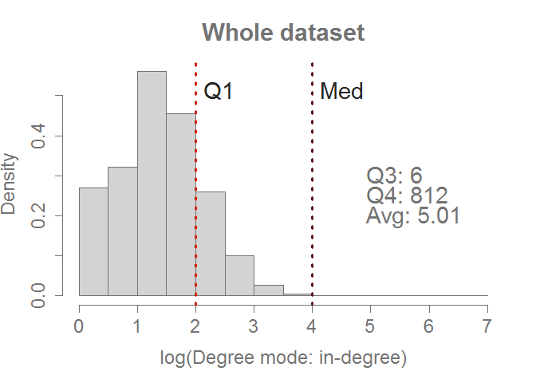

```r
#dev.off()


# In-degree

#png("Figures\\test.png", width = 40, height = 25, units = "cm", res = 300)
#par(mfrow=c(2,2))

hist(log(V(sn_g)$degree_in),
     probability = TRUE,
     main = "Whole dataset",
     xlab = 'log(Degree mode: in-degree)',
     border = "#737373",
     col.main = "#737373",
     col.lab = "#737373",
     cex.main = 1.9,
     cex.lab = 1.5,
     xaxt = 'n',
     yaxt = 'n'
)
axis(1,
     col = "#737373",
     col.ticks = "#737373",
     col.axis = "#737373",
     cex.axis = 1.5)
axis(2,
     col = "#737373",
     col.ticks = "#737373",
     col.axis = "#737373",
     cex.axis = 1.5)
abline(v = median(V(sn_g)$degree_in),
       col = "#5B1A18",
       lwd = 3,
       lty = 3)
text(median(V(sn_g)$degree_in), y=0.51, "Med", pos = 4, col = "#252525", cex = 1.8)
abline(v =quantile(V(sn_g)$degree_in, probs = 0.25),
       col = "#CB2314",
       lwd = 3,
       lty = 3)
text(quantile(V(sn_g)$degree_in, probs = 0.25), y=0.51, "Q1", pos = 4, col = "#252525", cex = 1.8)

q3 <- str_c("Q3", ": ", quantile(V(sn_g)$degree_in, probs = 0.75))
text(x=4.8, y=0.3, q3, pos = 4, col = "#737373", cex = 1.8)

q4 <- str_c("Q4", ": ", quantile(V(sn_g)$degree_in, probs = 1))
text(x=4.8, y=0.25, q4, pos = 4, col = "#737373", cex = 1.8)

avg_deg <- str_c("Avg", ": ", round(mean(V(sn_g)$degree_in), 2))
text(x=4.8, y=0.2, avg_deg, pos = 4, col = "#737373", cex = 1.8)
```

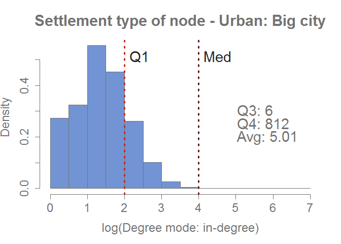

```r
# Urban: Big City
hist(log(V(sn_g_urb_bigcity)$degree_in),
     probability = TRUE,
     main = "Settlement type of node - Urban: Big city",
     xlab = 'log(Degree mode: in-degree)',
     col = "#7294D4",
     border = "#737373",
     col.main = "#737373",
     col.lab = "#737373",
     cex.main = 1.9,
     cex.lab = 1.5,
     xaxt = 'n',
     yaxt = 'n'
)
axis(1,
     col = "#737373",
     col.ticks = "#737373",
     col.axis = "#737373",
     cex.axis = 1.5)
axis(2,
     col = "#737373",
     col.ticks = "#737373",
     col.axis = "#737373",
     cex.axis = 1.5)
abline(v = median(V(sn_g_urb_bigcity)$degree_in),
       col = "#5B1A18",
       lwd = 3,
       lty = 3)
text(median(V(sn_g_urb_bigcity)$degree_in), y=0.51, "Med", pos = 4, col = "#252525", cex = 1.8)
abline(v =quantile(V(sn_g_urb_bigcity)$degree_in, probs = 0.25),
       col = "#CB2314",
       lwd = 3,
       lty = 3)
text(quantile(V(sn_g_urb_bigcity)$degree_in, probs = 0.25), y=0.51, "Q1", pos = 4, col = "#252525", cex = 1.8)

q3 <- str_c("Q3", ": ", quantile(V(sn_g_urb_bigcity)$degree_in, probs = 0.75))
text(x=4.9, y=0.3, q3, pos = 4, col = "#737373", cex = 1.8)

q4 <- str_c("Q4", ": ", quantile(V(sn_g_urb_bigcity)$degree_in, probs = 1))
text(x=4.9, y=0.25, q4, pos = 4, col = "#737373", cex = 1.8)

avg_deg <- str_c("Avg", ": ", round(mean(V(sn_g_urb_bigcity)$degree_in), 2))
text(x=4.9, y=0.2, avg_deg, pos = 4, col = "#737373", cex = 1.8)
```

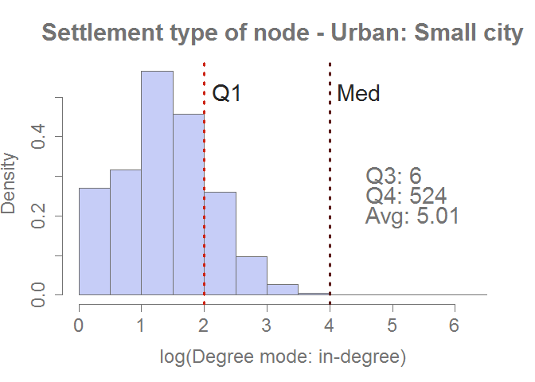

```r
# Urban: Small city
hist(log(V(sn_g_urb_smallcity)$degree_in),
     probability = TRUE,
     main = "Settlement type of node - Urban: Small city",
     xlab = 'log(Degree mode: in-degree)',
     col = "#C6CDF7",
     border = "#737373",
     col.main = "#737373",
     col.lab = "#737373",
     cex.main = 1.9,
     cex.lab = 1.5,
     xaxt = 'n',
     yaxt = 'n'
)
axis(1,
     col = "#737373",
     col.ticks = "#737373",
     col.axis = "#737373",
     cex.axis = 1.5)
axis(2,
     col = "#737373",
     col.ticks = "#737373",
     col.axis = "#737373",
     cex.axis = 1.5)
abline(v = median(V(sn_g_urb_smallcity)$degree_in),
       col = "#5B1A18",
       lwd = 3,
       lty = 3)
text(median(V(sn_g_urb_smallcity)$degree_in), y=0.51, "Med", pos = 4, col = "#252525", cex = 1.8)
abline(v =quantile(V(sn_g_urb_smallcity)$degree_in, probs = 0.25),
       col = "#CB2314",
       lwd = 3,
       lty = 3)
text(quantile(V(sn_g_urb_smallcity)$degree_in, probs = 0.25), y=0.51, "Q1", pos = 4, col = "#252525", cex = 1.8)

q3 <- str_c("Q3", ": ", quantile(V(sn_g_urb_smallcity)$degree_in, probs = 0.75))
text(x=4.45, y=0.3, q3, pos = 4, col = "#737373", cex = 1.8)

q4 <- str_c("Q4", ": ", quantile(V(sn_g_urb_smallcity)$degree_in, probs = 1))
text(x=4.45, y=0.25, q4, pos = 4, col = "#737373", cex = 1.8)

avg_deg <- str_c("Avg", ": ", round(mean(V(sn_g_urb_smallcity)$degree_in), 2))
text(x=4.45, y=0.2, avg_deg, pos = 4, col = "#737373", cex = 1.8)
```

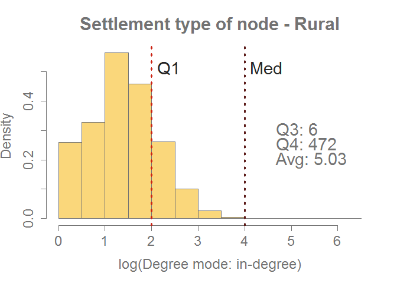

```r
# Rural
hist(log(V(sn_g_rural)$degree_in),
     probability = TRUE,
     main = "Settlement type of node - Rural",
     xlab = 'log(Degree mode: in-degree)',
     col = "#FAD77B",
     border = "#737373",
     col.main = "#737373",
     col.lab = "#737373",
     cex.main = 1.9,
     cex.lab = 1.5,
     xaxt = 'n',
     yaxt = 'n'
)
axis(1,
     col = "#737373",
     col.ticks = "#737373",
     col.axis = "#737373",
     cex.axis = 1.5)
axis(2,
     col = "#737373",
     col.ticks = "#737373",
     col.axis = "#737373",
     cex.axis = 1.5)
abline(v = median(V(sn_g_rural)$degree_in),
       col = "#5B1A18",
       lwd = 3,
       lty = 3)
text(median(V(sn_g_rural)$degree_in), y=0.51, "Med", pos = 4, col = "#252525", cex = 1.8)
abline(v =quantile(V(sn_g_rural)$degree_in, probs = 0.25),
       col = "#CB2314",
       lwd = 3,
       lty = 3)
text(quantile(V(sn_g_rural)$degree_in, probs = 0.25), y=0.51, "Q1", pos = 4, col = "#252525", cex = 1.8)

q3 <- str_c("Q3", ": ", quantile(V(sn_g_rural)$degree_in, probs = 0.75))
text(x=4.55, y=0.3, q3, pos = 4, col = "#737373", cex = 1.8)

q4 <- str_c("Q4", ": ", quantile(V(sn_g_rural)$degree_in, probs = 1))
text(x=4.55, y=0.25, q4, pos = 4, col = "#737373", cex = 1.8)

avg_deg <- str_c("Avg", ": ", round(mean(V(sn_g_rural)$degree_in), 2))
text(x=4.55, y=0.2, avg_deg, pos = 4, col = "#737373", cex = 1.8)
```

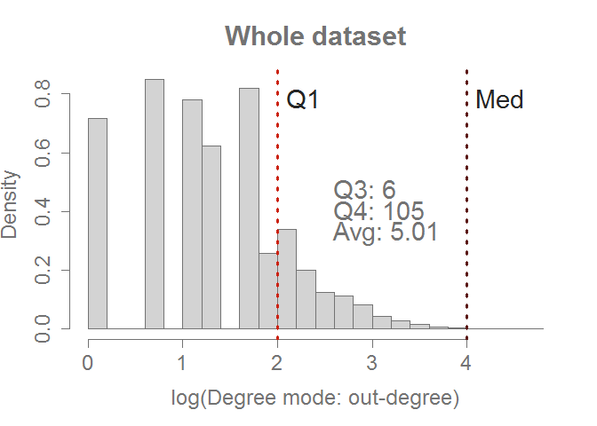

```r
#dev.off()


# Out-degree

#png("Figures\\test.png", width = 40, height = 25, units = "cm", res = 300)
#par(mfrow=c(2,2))

hist(log(V(sn_g)$degree_out),
     probability = TRUE,
     main = "Whole dataset",
     xlab = 'log(Degree mode: out-degree)',
     border = "#737373",
     col.main = "#737373",
     col.lab = "#737373",
     cex.main = 1.9,
     cex.lab = 1.5,
     xaxt = 'n',
     yaxt = 'n'
)
axis(1,
     col = "#737373",
     col.ticks = "#737373",
     col.axis = "#737373",
     cex.axis = 1.5)
axis(2,
     col = "#737373",
     col.ticks = "#737373",
     col.axis = "#737373",
     cex.axis = 1.5)
abline(v = median(V(sn_g)$degree_out),
       col = "#5B1A18",
       lwd = 3,
       lty = 3)
text(median(V(sn_g)$degree_out), y=0.78, "Med", pos = 4, col = "#252525", cex = 1.8)
abline(v =quantile(V(sn_g)$degree_out, probs = 0.25),
       col = "#CB2314",
       lwd = 3,
       lty = 3)
text(quantile(V(sn_g)$degree_out, probs = 0.25), y=0.78, "Q1", pos = 4, col = "#252525", cex = 1.8)

q3 <- str_c("Q3", ": ", quantile(V(sn_g)$degree_out, probs = 0.75))
text(x=2.5, y=0.47, q3, pos = 4, col = "#737373", cex = 1.8)

q4 <- str_c("Q4", ": ", quantile(V(sn_g)$degree_out, probs = 1))
text(x=2.5, y=0.4, q4, pos = 4, col = "#737373", cex = 1.8)

avg_deg <- str_c("Avg", ": ", round(mean(V(sn_g)$degree_out), 2))
text(x=2.5, y=0.33, avg_deg, pos = 4, col = "#737373", cex = 1.8)
```

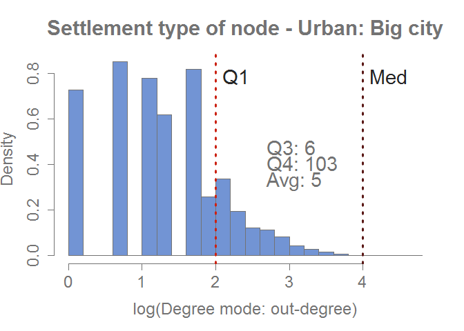

```r
# Urban: Big City
hist(log(V(sn_g_urb_bigcity)$degree_out),
     probability = TRUE,
     main = "Settlement type of node - Urban: Big city",
     xlab = 'log(Degree mode: out-degree)',
     col = "#7294D4",
     border = "#737373",
     col.main = "#737373",
     col.lab = "#737373",
     cex.main = 1.9,
     cex.lab = 1.5,
     xaxt = 'n',
     yaxt = 'n'
)
axis(1,
     col = "#737373",
     col.ticks = "#737373",
     col.axis = "#737373",
     cex.axis = 1.5)
axis(2,
     col = "#737373",
     col.ticks = "#737373",
     col.axis = "#737373",
     cex.axis = 1.5)
abline(v = median(V(sn_g_urb_bigcity)$degree_out),
       col = "#5B1A18",
       lwd = 3,
       lty = 3)
text(median(V(sn_g_urb_bigcity)$degree_out), y=0.78, "Med", pos = 4, col = "#252525", cex = 1.8)
abline(v =quantile(V(sn_g_urb_bigcity)$degree_out, probs = 0.25),
       col = "#CB2314",
       lwd = 3,
       lty = 3)
text(quantile(V(sn_g_urb_bigcity)$degree_out, probs = 0.25), y=0.78, "Q1", pos = 4, col = "#252525", cex = 1.8)

q3 <- str_c("Q3", ": ", quantile(V(sn_g_urb_bigcity)$degree_out, probs = 0.75))
text(x=2.6, y=0.47, q3, pos = 4, col = "#737373", cex = 1.8)

q4 <- str_c("Q4", ": ", quantile(V(sn_g_urb_bigcity)$degree_out, probs = 1))
text(x=2.6, y=0.4, q4, pos = 4, col = "#737373", cex = 1.8)

avg_deg <- str_c("Avg", ": ", round(mean(V(sn_g_urb_bigcity)$degree_out), 2))
text(x=2.6, y=0.33, avg_deg, pos = 4, col = "#737373", cex = 1.8)
```